# Downstream analysis I: genes differentially expressed along a ligand-receptor field trajectory

Kai Li

2026-10-15

The previous tutorials stop at the field: they show how to estimate the ligand-receptor interaction as a spatial vector field, and how to score and visualise it. This one asks a transcriptional question:

**Along the direction in which a ligand-receptor pair signals, which genes change their expression?**

Answering it means treating a field quantity as a trajectory. Take one LR pair and look at its field potential `U`: every spot now sits at some position on the ligand-to-receptor axis, and gene expression can be modelled as a function of that position. We use tradeSeq to fit that function, which is why it is listed as a suggested dependency of spWAVE.

## Setup

```r
library(magrittr)
library(dplyr)

library(Seurat)
library(ggplot2)
library(spWAVE)
```

## Rebuild the field

We reuse the 10x Visium mouse brain dataset and the small TGFb/FGF database from the first tutorial, so the field values here are the same ones. The field takes a few seconds; the trajectory fit below takes several minutes.

```r
#** folder holding the tutorial dataset, adjust it to your local copy
data_dir <- "../../data"
brain <- readRDS(file.path(data_dir, "mouse_brain_anno_clu.rds"))

mouse_db <-
  load_database(db_source = "CellChat", db_species = "mouse", filter_type = "Secreted")
#** a smaller subset, as in the field tutorials
mouse_db %<>% dplyr::filter(Family %in% c("TGFb", "FGF"))

brain_spWAVE <- create_spWAVE_object(brain, mouse_db, assay = "SCT")
brain_spWAVE <- brain_spWAVE %>% perform_LR_field_calc()
```

```
#> [1] "Step1. calc single molecule or complex field"
#> [1] "Step2. calc LR pair or family field"
#>   |                                                                              |                                                                      |   0%  |                                                                              |==                                                       …
#>   |                                                                              |                                                                      |   0%  |                                                                              |===================================                      …
```

## The trajectory is the field itself

Extracting one LR pair gives a data.frame with the field vector (`Ex`, `Ey`), the field potential (`U`), the ligand and receptor expression, and their difference.

```r
fgf1 <- perform_field_extract(brain_spWAVE, "Fgf1.Fgfr1")
fgf1 %>% head
```

```
#>                           y        x            barcode            Ex
#> AAACAAGTATCTCCCA-1 4607.621 6213.208 AAACAAGTATCTCCCA-1  4.400470e-04
#> AAACACCAATAACTGC-1 3824.797 2063.081 AAACACCAATAACTGC-1  1.848817e-04
#> AAACAGCTTTCAGAAG-1 5216.887 1562.742 AAACAGCTTTCAGAAG-1  1.311554e-04
#> AAACAGGGTCTATATT-1 4868.320 1763.168 AAACAGGGTCTATATT-1 -7.469621e-05
#> AAACAGTGTTCCTGGG-1 2606.265 3262.733 AAACAGTGTTCCTGGG-1 -1.144690e-04
#> AAACATTTCCCGGATT-1 3650.514 5963.401 AAACATTTCCCGGATT-1 -1.029766e-04
#>                               Ey           U      Fgf1     Fgfr1 Rel_LR_Exp
#> AAACAAGTATCTCCCA-1  0.0002181545  0.14009258 1.3862944 0.6931472  0.6931472
#> AAACACCAATAACTGC-1 -0.0005181574  0.00904740 0.6931472 0.6931472  0.0000000
#> AAACAGCTTTCAGAAG-1  0.0002395317 -0.03772395 1.0986123 0.0000000  1.0986123
#> AAACAGGGTCTATATT-1 -0.0002256145  0.05111014 0.6931472 0.0000000  0.6931472
#> AAACAGTGTTCCTGGG-1  0.0000195163 -0.08352131 0.0000000 0.6931472 -0.6931472
#> AAACATTTCCCGGATT-1 -0.0004868262  0.09508120 0.0000000 1.3862944 -1.3862944
#>                              KEx           KEy   E_strength            KU
#> AAACAAGTATCTCCCA-1  3.501782e-05  1.736018e-05 3.908483e-05  0.0111482131
#> AAACACCAATAACTGC-1  1.471242e-05 -4.123366e-05 4.377979e-05  0.0007199692
#> AAACAGCTTTCAGAAG-1  1.043702e-05  1.906132e-05 2.173167e-05 -0.0030019769
#> AAACAGGGTCTATATT-1 -5.944136e-06 -1.795383e-05 1.891224e-05  0.0040672158
#> AAACAGTGTTCCTGGG-1 -9.109151e-06  1.553058e-06 9.240597e-06 -0.0066464151
#> AAACATTTCCCGGATT-1 -8.194620e-06 -3.874040e-05 3.959761e-05  0.0075663212
```

`U` is what we will use as the trajectory: the question is which genes, in the space the field potential lays out, are expressed along the way that space is arranged – so `U` goes in as the trajectory variable. Two things are worth being explicit about:

- **it is not a lineage pseudotime.** Nothing is inferred about cell state ordering; `U` is a spatial quantity, and cells with the same potential are simply “equally far” along the ligand-to-receptor direction. Every cell joins the same single trajectory, which is why the cell weights are all 1.
- **the sign has a direction.** A ligand field contributes positively to the potential and the receptor field negatively, so genes going up along `U` are the ones tracking the ligand side of the interaction.

The column name is itself an argument: `traj_arg` accepts any column of this data.frame, so `Ex`, `Ey` or `E_strength` can be used the same way. Which of them to hand it is a question about how you read the field space – the direction of the field, or only how strong it is – rather than about the method.

## Fit the trajectory

The fit is the expensive step of this tutorial, so the call is shown here rather than run. The chunk after it loads a result computed in advance.

```r
brain_fgf1 <- run_LR_tradeSeq(
  seurat_obj = brain,
  database_result = brain_spWAVE,
  LR = "Fgf1.Fgfr1",
  kept_db = brain_spWAVE@kept_db,
  traj_arg = "U",
  nknots = 6,
  parallel = TRUE,
  paral_workers = 2
)
```

Two things decide the cost: the fit covers every gene of the assay, not only the ligand and the receptor, and `paral_workers` trades memory for time rather than being a free speedup.

```r
#** the object the call above returns
brain_fgf1 <- readRDS(file.path(data_dir, "fgf1_trade_res.rds"))
```

The returned list carries both the fitted model and the `field_df` it was built from; the second is not optional, because the plotting step below needs it.

## Test genes along the trajectory

```r
fgf1_test <- run_tradeSeq_gene_test(brain_fgf1$trade_res, method_use = "association")
fgf1_test %>% head
```

```
#>          waldStat df pvalue meanLogFC p.adj
#> Fth1    1576.4486  3      0 0.7324038     0
#> Nrgn    1434.3478  3      0 1.0059456     0
#> Camk2n1 1124.6110  3      0 0.3649443     0
#> Mbp     1081.8579  3      0 0.6851428     0
#> Camk2a  1000.0012  3      0 0.7276876     0
#> Fbxl16   921.3384  3      0 0.4378477     0
```

`run_tradeSeq_gene_test` wraps the two tradeSeq tests: `"association"` asks whether a gene’s expression changes at all along the trajectory, `"startvsend"` only asks whether the two ends of the trajectory differ. Both fill the genes whose GAM did not converge with neutral values instead of dropping them, and both report BH-adjusted p-values.

The test here is deliberately permissive – thousands of genes come back significant – because it tests a spatial gradient over a few thousand spots, not a designed contrast. Rank genes by `waldStat`, rather than reading the p-value column as a list of discoveries. The table comes back sorted by it, so the top of it is the ranking; we carry the first 200 genes into the figures below.

```r
top_genes <- head(rownames(fgf1_test), 200)
```

## Visualise the trajectory genes

```
#>   [1] "Fth1"          "Nrgn"          "Camk2n1"       "Mbp"
#>   [5] "Camk2a"        "Fbxl16"        "Cck"           "Plp1"
#>   [9] "Trf"           "Cpe"           "Gpm6a"         "Vamp2"
#>  [13] "Mobp"          "Scd2"          "Wipf3"         "Plekhb1"
#>  [17] "Mag"           "Car2"          "Cnp"           "Bcas1"
#>  [21] "Stx1a"         "Dbndd2"        "Syt1"          "Ctxn1"
#>  [25] "Calm1"         "Tspan7"        "Ddn"           "Pacs2"
#>  [29] "Cryab"         "Hpcal4"        "Qdpr"          "Hcn2"
#>  [33] "Olfm1"         "Nptxr"         "Ndrg1"         "Selenop"
#>  [37] "Aplp1"         "Tubb4a"        "Mef2c"         "Pcp4"
#>  [41] "Arhgef25"      "Gatm"          "Ppp1r14a"      "Selenow"
#>  [45] "Dbn1"          "Mog"           "Slc17a7"       "Tpt1"
#>  [49] "Gng11"         "Chd3"          "Kcnh3"         "Qk"
#>  [53] "Psd"           "Ermn"          "Pllp"          "Klk6"
#>  [57] "Ugt8a"         "Mal"           "Kalrn"         "C1qtnf4"
```

[output cut: 35 more lines]

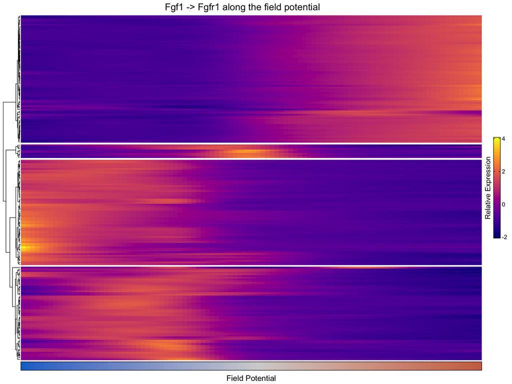

```r
ht_main <- plot_tradeTest_heatmap(
  brain_fgf1$trade_res,
  fgf1_test,
  brain_fgf1$field_df,
  select_genes = top_genes,
  n_split_row = 4,
  title = "Fgf1 -> Fgfr1 along the field potential"
)
```

Rows are genes, columns are positions along the trajectory, and the colour is expression after `predictSmooth` has evaluated each gene’s GAM at 100 points and each row has been scaled. So a row is not “expression in a cell” but “the shape of this gene’s response”. The `Potential` annotation bar underneath is the trajectory itself: mid grey is `U = 0`, blue is negative, red is positive. That is what makes the figure readable – a gene block that brightens towards the red end is induced on the ligand side.

`select_genes` takes any gene list, so the same call shows an arbitrary set of genes by name – it masks both `top_n_gene` and `order_by`. The two block figures below are drawn that way.

## What the trajectory genes are

Each block is a group of genes with the same response shape, so the blocks are the natural unit to test. They do not have to be recovered by clustering again: the split is already in the figure, and `row_order()` reads the members of each block straight off it.

```r
#** row_order() indexes the rows of the matrix the heatmap was drawn from, which is the
#** gene vector that was passed in -- so the block members are read off by position
block_genes <- ComplexHeatmap::row_order(ht_main) %>% lapply(function(i) top_genes[i])
lengths(block_genes)
```

```
#>  1  2  3  4
#> 75  8 62 55
```

```r
#** the two largest blocks, labelled by the direction their mean response runs in
yhat   <- tradeSeq::predictSmooth(brain_fgf1$trade_res, gene = top_genes, nPoints = 100, tidy = FALSE)
scaled <- t(scale(t(yhat)))
big <- names(sort(lengths(block_genes), decreasing = TRUE))[1:2]
rise <- sapply(big, function(b) { p <- colMeans(scaled[block_genes[[b]], , drop = FALSE]); p[100] - p[1] })
big <- big[order(-rise)]
names(big) <- ifelse(sort(rise, decreasing = TRUE) > 0, "rising (ligand side)", "falling (receptor side)")
names(big)
```

```
#> [1] "rising (ligand side)"    "falling (receptor side)"
```

The two blocks run in opposite directions, so each is worth looking at on its own. One figure per block, with the members of that block as `select_genes` and their names shown; the two are drawn side by side.

```
#>  [1] "Tubb4a"    "Sez6l2"    "Qk"        "Kcnj10"    "Scd2"      "Olig1"
#>  [7] "Hmgcs1"    "Pacs2"     "Anln"      "Pip4k2a"   "Fez1"      "Josd2"
#> [13] "Gsn"       "Car2"      "Ppp1r14a"  "Endod1"    "Gltp"      "Trp53inp2"
#> [19] "Hcn2"      "Gng11"     "Bcas1"     "Mobp"      "Pdlim2"    "Cryab"
#> [25] "Plekhb1"   "Mag"       "Plp1"      "Pllp"      "Ugt8a"     "Taldo1"
#> [31] "Fa2h"      "Gatm"      "Dbndd2"    "Psat1"     "Selenop"   "Trf"
#> [37] "Hapln2"    "Ermn"      "Cmtm5"     "Fth1"      "Sirt2"     "Klk6"
#> [43] "Mbp"       "Sccpdh"    "Ndrg1"     "Pmp22"     "Sec11c"    "Gjb1"
#> [49] "Efcab14"   "Gjc2"      "Tpt1"      "Prdx1"     "Aplp1"     "Rhob"
#> [55] "Efnb3"     "Malat1"    "Nefm"      "Vamp1"     "Nefl"      "Csrp1"
#> [61] "Cd81"      "Cldn11"    "Tspan2"    "Mal"       "Tmem88b"   "Cnp"
#> [67] "Qdpr"      "Mog"       "Gpr37"     "Prr18"     "Slc44a1"   "Rnf13"
#> [73] "Lamp1"     "Tppp3"     "Enpp2"
#>  [1] "Gria2"         "Ly6h"          "Dkk3"          "Hpcal4"
#>  [5] "Olfm1"         "Ctxn1"         "Plppr4"        "Enc1"
#>  [9] "Rprml"         "Camkv"         "Chn1"          "Mmp17"
#> [13] "Sprn"          "Nell2"         "Mal2"          "Cnksr2"
#> [17] "Celf5"         "Baiap2"        "Cacnb3"        "Nrgn"
#> [21] "Rasgef1a"      "Mical2"        "Arf3"          "Kcnj4"
#> [25] "Kcnh3"         "Slc30a3"       "Ptk2b"         "Foxg1"
#> [29] "Icam5"         "Fam131a"       "Abr"           "Chd3"
#> [33] "Ssbp4"         "Tspan13"       "Gria1"         "Dbn1"
#> [37] "Ppp3ca"        "Arhgef25"      "2010300C02Rik" "Adgrb2"
#> [41] "Cplx2"         "Dlgap1"        "Fbxl16"        "Itpka"
#> [45] "Lhx2"          "Egr3"          "Chrm1"         "Kalrn"
#> [49] "Tspan7"        "Wipf3"         "Cnih2"         "Ddn"
#> [53] "Psd"           "Camk2a"        "Nsmf"          "Shank3"
#> [57] "Camk2b"        "Dlgap3"        "Atp2b1"        "Cpe"
#> [61] "Sptbn2"        "Selenow"
```

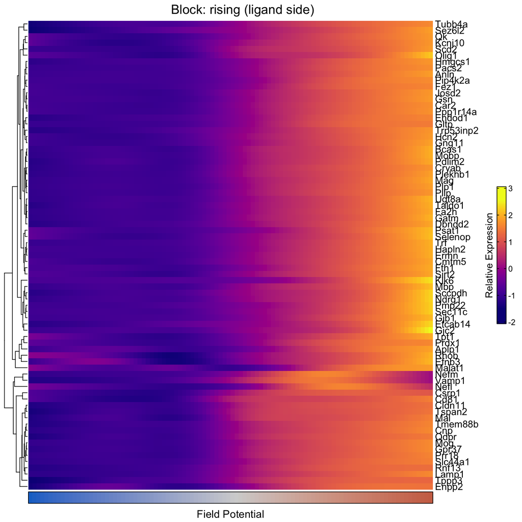

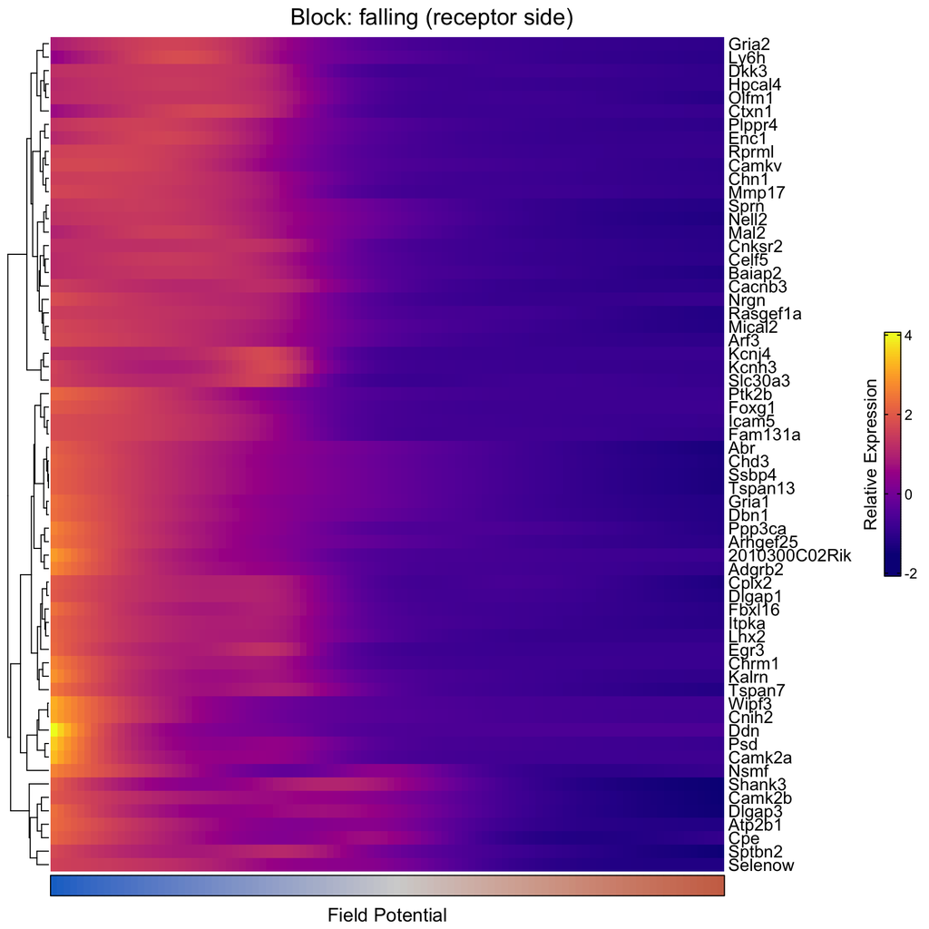

```r
block_ht <- Map(function(genes, label)
  plot_tradeTest_heatmap(
    brain_fgf1$trade_res,
    fgf1_test,
    brain_fgf1$field_df,
    select_genes  = genes,
    show_rownames = TRUE,
    n_split_row   = 1,
    title         = paste0("Block: ", label)
  ),
  block_genes[big], names(big))
```

Then a plain over-representation test per block. The universe is the set of genes that were actually fitted, not the genome: a whole-genome background would report the expression filter as if it were enrichment.

```r
library(clusterProfiler)
library(org.Mm.eg.db)   # Bioconductor mouse annotation

block_enrich <- lapply(big, function(b)
  enrichGO(block_genes[[b]], OrgDb = org.Mm.eg.db, keyType = "SYMBOL", ont = "BP",
           universe = rownames(fgf1_test), pAdjustMethod = "BH",
           pvalueCutoff = 0.05, qvalueCutoff = 0.2, readable = TRUE))
```

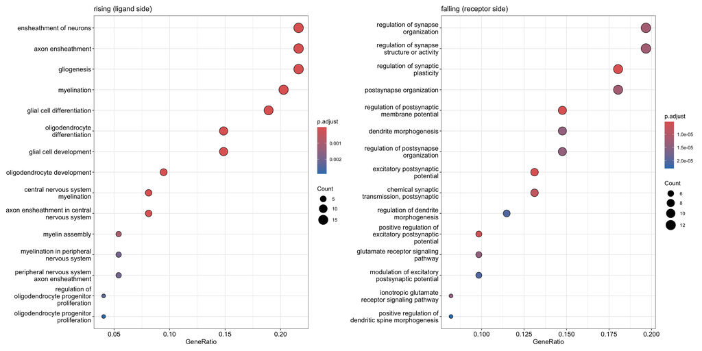

```r
library(enrichplot)
library(patchwork)
wrap_plots(Map(function(eg, l) dotplot(eg, showCategory = 15) + ggtitle(l),
               block_enrich, names(big)), ncol = 2)
```

Each block comes back as one family and no term appears in both: the rising block is myelin and oligodendrocyte terms (ensheathment of neurons, myelination, oligodendrocyte differentiation), the falling block is synaptic terms (synapse organization, postsynaptic membrane potential, glutamate receptor signalling). `U` is a spatial axis, so a block that tracks it also tracks anatomy – here the positive end is hindbrain, the negative end hippocampus and cortex.